# Tissue Specificity in *Syngnathus floridae*

Coley Tosto

2023-11-07

```r
#Create the DESeq dataset
dds_FL <- DESeqDataSetFromTximport(txi.salmon,
                                   colData = samples,
                                   design = ~ group)

#only keeping rows that have at lead 10 reads total
keep <- rowSums(counts(dds_FL)) >= 10
dds_FL <- dds_FL[keep, ]

#Generate the expression values
dds_FL_exp <- DESeq(dds_FL)
```

To estimate tissue specificity, the TPM estimates are needed which is the number of transcripts from a particular gene normalized first by gene length, and then by sequencing depth (in millions) in the sample. The output quant.sf files from salmon have the following format:

```
Name | Length | EffectiveLength | TPM | NumReads
```

From these salmon outputs we can then pull out the TPM values for each sample.

```r
files <- list.files(pattern = ".sf", path = "data/floridae_expression_files",
                    full.names = TRUE)

tpms <- do.call(cbind, lapply(files, function(file){
  #browser()
  dat <- read.delim(file, row.names = "Name")
  tpm <- dat["TPM"]
  colnames(tpm) <- gsub("data/floridae_expression_files/(.*)_quant.sf","\\1",file)

  return(tpm)
}))
```

Once all the TPMs were gathered for the different samples I filtered some of the rows out based on results from DESeq2. It should be noted that the DESeq2 filtering was done based off of the count data and not the TPMs, but as TPMs are just normalized counts they should be correlated and something that was had low gene counts should also have a low TPM and anything that was considered an outlier in the counts could also be an outlier in terms of TPM, but it may not be perfect.

```r
#Only keeping the rows that weren't filtered out due to low counts
tpms <- tpms[rownames(tpms) %in% rownames(dds_FL), ]

#Pulling out the geneIDs for genes that were categorized as "outliers" by DESeq2
#Calculating the Cooks threshold that would have been used
np <- length(resultsNames(dds_FL_exp))
nsamp <- ncol(dds_FL_exp)
cooks_thresh <- qf(0.99, df1 = np, df2 = 29-np)

out_ids <- names(mcols(dds_FL_exp)$maxCooks[mcols(dds_FL_exp)$maxCooks > cooks_thresh])

#Removing the rows in the tpm dataset that were deemed "outliers" by DESeq2
tpms <- tpms[!(rownames(tpms) %in% out_ids), ]
```

These TPM estimates can then be used to estimate $\tau$, a tissue specificity estimator that can range from 0 to 1. $\tau$ is calculated for each tissue, $i$, as follows:

```r
est_tau<-function(geneDat,colDat){

  tissue_dat<-data.frame(cbind(colDat,
                               geneDat))
  #browser()
  tissue_dat$geneDat[tissue_dat$geneDat<1]<-2


  #tpmMax<-max(tissue_dat$geneDat)
  tissue_avgs<-tapply(tissue_dat$geneDat,tissue_dat$Organ,mean)
  tpmMax <- max(tissue_avgs, na.rm=TRUE)

  #tissue_avgs[tissue_avgs<1]<-2
  if(length(unique(tissue_dat$Organ)) == 3){
    tau <- sum(1-(log(tissue_avgs[unique(tissue_dat$Organ)])/log(tpmMax)))/(length(unique(tissue_dat$Organ))-1)

    return(tau)
  }

  tau<-sum(1-(log(tissue_avgs)/log(tpmMax)))/(length(unique(tissue_dat$Organ))-1)

  return(tau)
}
```

```r
tau <- apply(tpms, 1, est_tau, colDat=colData)


tau_fem<-apply(tpms[,which(colData$Sex=="F")], 1, est_tau,
               colData[which(colData$Sex=="F"),])

tau_mal<-apply(tpms[,which(colData$Sex=="M")], 1, est_tau,
               colData[which(colData$Sex=="M"),])
```

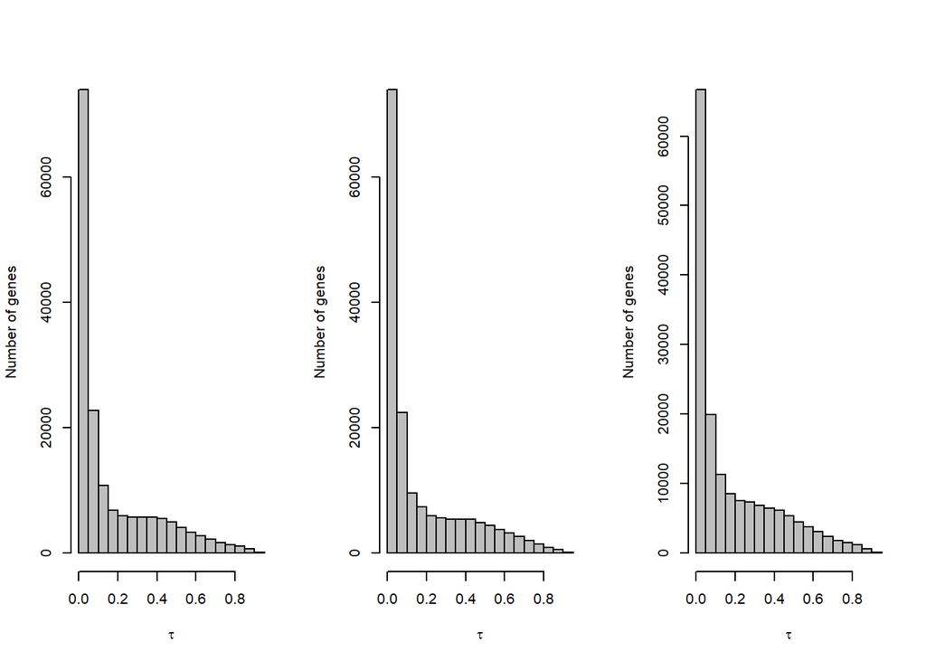

Distribution of tissue specificity estimates for only the male samples (left) versus only the female samples (middle) versus the male samples and the female samples (right).

Let’s now investigate some of the plot counts for the genes with a high tissue specificity index.

```
## named numeric(0)
```

```
## TRINITY_DN4937_c1_g1
##            0.9400684
```

|  | FLG2F7 | FLG3F1 | FLG3F2 | FLG3M5 | FLG3M7 | FLG3M8 | FLG4M3 | FLG4M4 | FLG8F3 | FLL2F7 | FLL3F1 | FLL3F2 | FLL3F4 | FLL3M5 | FLL3M7 | FLL3M8 | FLL4M3 | FLL4M4 | FLL8F3 | FLO2F7 | FLO3F1 | FLO3F2 | FLO3F4 | FLO8F3 | FLT2M3 | FLT3M5 | FLT4M4 | FLT5M3 | FLT8M7 |
| --- | --- | --- | --- | --- | --- | --- | --- | --- | --- | --- | --- | --- | --- | --- | --- | --- | --- | --- | --- | --- | --- | --- | --- | --- | --- | --- | --- | --- | --- |
| TRINITY_DN79971_c0_g1 | 0 | 0.22401 | 1.467807 | 0 | 0 | 0.524378 | 1.357382 | 2.201918 | 0.123275 | 2.618225 | 1.054227 | 2.438477 | 0.835499 | 0.068457 | 0.665254 | 0.580137 | 7.961344 | 118.5182 | 1.335837 | 0 | 0 | 0.353455 | 0 | 0 | 0.172507 | 0 | 0.3445 | 0 | 0 |

```
## using 'avgTxLength' from assays(dds), correcting for library size
```

|  | FLG2F7 | FLG3F1 | FLG3F2 | FLG3M5 | FLG3M7 | FLG3M8 | FLG4M3 | FLG4M4 | FLG8F3 | FLL2F7 | FLL3F1 | FLL3F2 | FLL3F4 | FLL3M5 | FLL3M7 | FLL3M8 | FLL4M3 | FLL4M4 | FLL8F3 | FLO2F7 | FLO3F1 | FLO3F2 | FLO3F4 | FLO8F3 | FLT2M3 | FLT3M5 | FLT4M4 | FLT5M3 | FLT8M7 |
| --- | --- | --- | --- | --- | --- | --- | --- | --- | --- | --- | --- | --- | --- | --- | --- | --- | --- | --- | --- | --- | --- | --- | --- | --- | --- | --- | --- | --- | --- |
| TRINITY_DN33844_c0_g1 | 2.173862 | 1.58947 | 2.009153 | 0.758988 | 0.847319 | 5.510411 | 2.528495 | 59.9265 | 0 | 1.105366 | 1.418612 | 0 | 1.619898 | 0 | 0.381859 | 1.095565 | 0.524579 | 0.862077 | 0.604758 | 0.863839 | 0.658435 | 0 | 1.173996 | 2.537471 | 0.793188 | 1.885087 | 0 | 0 | 0.885463 |

```
## using 'avgTxLength' from assays(dds), correcting for library size
```

|  | FLG2F7 | FLG3F1 | FLG3F2 | FLG3M5 | FLG3M7 | FLG3M8 | FLG4M3 | FLG4M4 | FLG8F3 | FLL2F7 | FLL3F1 | FLL3F2 | FLL3F4 | FLL3M5 | FLL3M7 | FLL3M8 | FLL4M3 | FLL4M4 | FLL8F3 | FLO2F7 | FLO3F1 | FLO3F2 | FLO3F4 | FLO8F3 | FLT2M3 | FLT3M5 | FLT4M4 | FLT5M3 | FLT8M7 |
| --- | --- | --- | --- | --- | --- | --- | --- | --- | --- | --- | --- | --- | --- | --- | --- | --- | --- | --- | --- | --- | --- | --- | --- | --- | --- | --- | --- | --- | --- |
| TRINITY_DN32505_c0_g2 | 0 | 0 | 0 | 0 | 0 | 0 | 0 | 0 | 0 | 0 | 0 | 11.72874 | 81.76168 | 0 | 0 | 0 | 0 | 0 | 0 | 0 | 0 | 0 | 0 | 0 | 0.336207 | 0 | 0 | 1.232252 | 0.662413 |

```
## using 'avgTxLength' from assays(dds), correcting for library size
```

|  | FLG2F7 | FLG3F1 | FLG3F2 | FLG3M5 | FLG3M7 | FLG3M8 | FLG4M3 | FLG4M4 | FLG8F3 | FLL2F7 | FLL3F1 | FLL3F2 | FLL3F4 | FLL3M5 | FLL3M7 | FLL3M8 | FLL4M3 | FLL4M4 | FLL8F3 | FLO2F7 | FLO3F1 | FLO3F2 | FLO3F4 | FLO8F3 | FLT2M3 | FLT3M5 | FLT4M4 | FLT5M3 | FLT8M7 |
| --- | --- | --- | --- | --- | --- | --- | --- | --- | --- | --- | --- | --- | --- | --- | --- | --- | --- | --- | --- | --- | --- | --- | --- | --- | --- | --- | --- | --- | --- |
| TRINITY_DN17266_c0_g2 | 2.746994 | 172.7351 | 0 | 3.219645 | 0 | 1.901685 | 9.51915 | 0 | 13.24765 | 0 | 0 | 0 | 0 | 0 | 0 | 0 | 0 | 0 | 0 | 0 | 0 | 0 | 0.103716 | 1.120032 | 0 | 0 | 0.069393 | 0.715632 | 0 |

```
## using 'avgTxLength' from assays(dds), correcting for library size
```

|  | FLG2F7 | FLG3F1 | FLG3F2 | FLG3M5 | FLG3M7 | FLG3M8 | FLG4M3 | FLG4M4 | FLG8F3 | FLL2F7 | FLL3F1 | FLL3F2 | FLL3F4 | FLL3M5 | FLL3M7 | FLL3M8 | FLL4M3 | FLL4M4 | FLL8F3 | FLO2F7 | FLO3F1 | FLO3F2 | FLO3F4 | FLO8F3 | FLT2M3 | FLT3M5 | FLT4M4 | FLT5M3 | FLT8M7 |
| --- | --- | --- | --- | --- | --- | --- | --- | --- | --- | --- | --- | --- | --- | --- | --- | --- | --- | --- | --- | --- | --- | --- | --- | --- | --- | --- | --- | --- | --- |
| TRINITY_DN71047_c0_g1 | 0 | 0 | 0 | 0 | 0 | 0.93237 | 0.5407 | 0.527475 | 0.15202 | 3.498205 | 1.270062 | 1.820162 | 1.393168 | 0.166199 | 2.193122 | 788.7528 | 27.96898 | 0.202476 | 11.25624 | 0 | 0.173856 | 0 | 0 | 0.415763 | 0 | 0 | 0 | 0 | 0 |

```
## using 'avgTxLength' from assays(dds), correcting for library size
```

|  | FLG2F7 | FLG3F1 | FLG3F2 | FLG3M5 | FLG3M7 | FLG3M8 | FLG4M3 | FLG4M4 | FLG8F3 | FLL2F7 | FLL3F1 | FLL3F2 | FLL3F4 | FLL3M5 | FLL3M7 | FLL3M8 | FLL4M3 | FLL4M4 | FLL8F3 | FLO2F7 | FLO3F1 | FLO3F2 | FLO3F4 | FLO8F3 | FLT2M3 | FLT3M5 | FLT4M4 | FLT5M3 | FLT8M7 |
| --- | --- | --- | --- | --- | --- | --- | --- | --- | --- | --- | --- | --- | --- | --- | --- | --- | --- | --- | --- | --- | --- | --- | --- | --- | --- | --- | --- | --- | --- |
| TRINITY_DN927_c6_g2 | 0 | 0 | 0 | 0 | 0 | 0 | 0 | 0 | 0 | 0.386974 | 0 | 13.04647 | 162.5054 | 0 | 0 | 0 | 0 | 0.92337 | 0 | 1.732552 | 0 | 0 | 0 | 0 | 0.637396 | 0 | 0 | 0 | 0.646855 |

```
## using 'avgTxLength' from assays(dds), correcting for library size
```

|  | FLG2F7 | FLG3F1 | FLG3F2 | FLG3M5 | FLG3M7 | FLG3M8 | FLG4M3 | FLG4M4 | FLG8F3 | FLL2F7 | FLL3F1 | FLL3F2 | FLL3F4 | FLL3M5 | FLL3M7 | FLL3M8 | FLL4M3 | FLL4M4 | FLL8F3 | FLO2F7 | FLO3F1 | FLO3F2 | FLO3F4 | FLO8F3 | FLT2M3 | FLT3M5 | FLT4M4 | FLT5M3 | FLT8M7 |
| --- | --- | --- | --- | --- | --- | --- | --- | --- | --- | --- | --- | --- | --- | --- | --- | --- | --- | --- | --- | --- | --- | --- | --- | --- | --- | --- | --- | --- | --- |
| TRINITY_DN37495_c0_g1 | 0 | 0.479101 | 0 | 0 | 0 | 0 | 0 | 0 | 0 | 0.89563 | 88.99382 | 0.335787 | 0.296697 | 0.197344 | 0.631658 | 2.494548 | 1.463013 | 2.514473 | 3.961195 | 0 | 1.698259 | 0.753874 | 0 | 0 | 0 | 0 | 0 | 0 | 0 |

```
## using 'avgTxLength' from assays(dds), correcting for library size
```

|  | FLG2F7 | FLG3F1 | FLG3F2 | FLG3M5 | FLG3M7 | FLG3M8 | FLG4M3 | FLG4M4 | FLG8F3 | FLL2F7 | FLL3F1 | FLL3F2 | FLL3F4 | FLL3M5 | FLL3M7 | FLL3M8 | FLL4M3 | FLL4M4 | FLL8F3 | FLO2F7 | FLO3F1 | FLO3F2 | FLO3F4 | FLO8F3 | FLT2M3 | FLT3M5 | FLT4M4 | FLT5M3 | FLT8M7 |
| --- | --- | --- | --- | --- | --- | --- | --- | --- | --- | --- | --- | --- | --- | --- | --- | --- | --- | --- | --- | --- | --- | --- | --- | --- | --- | --- | --- | --- | --- |
| TRINITY_DN2652_c2_g1 | 1.089246 | 0.185818 | 2.297256 | 1.367329 | 0 | 0.207352 | 0 | 0 | 1.627541 | 0.517962 | 0 | 0.530727 | 109.5318 | 0 | 0.124085 | 0 | 0 | 0 | 7.187611 | 0 | 0 | 0 | 0.963106 | 0.881694 | 0 | 0 | 0 | 0 | 0 |

```
## using 'avgTxLength' from assays(dds), correcting for library size
```

|  | FLG2F7 | FLG3F1 | FLG3F2 | FLG3M5 | FLG3M7 | FLG3M8 | FLG4M3 | FLG4M4 | FLG8F3 | FLL2F7 | FLL3F1 | FLL3F2 | FLL3F4 | FLL3M5 | FLL3M7 | FLL3M8 | FLL4M3 | FLL4M4 | FLL8F3 | FLO2F7 | FLO3F1 | FLO3F2 | FLO3F4 | FLO8F3 | FLT2M3 | FLT3M5 | FLT4M4 | FLT5M3 | FLT8M7 |
| --- | --- | --- | --- | --- | --- | --- | --- | --- | --- | --- | --- | --- | --- | --- | --- | --- | --- | --- | --- | --- | --- | --- | --- | --- | --- | --- | --- | --- | --- |
| TRINITY_DN29035_c1_g1 | 1.911056 | 7.444657 | 3.207478 | 2.052365 | 5.227144 | 41.86098 | 0.764862 | 3.383421 | 0.832816 | 0 | 0 | 0.711857 | 2.099761 | 0.906164 | 1.008221 | 4.493387 | 0 | 0 | 0.786662 | 0 | 1.716189 | 1.202728 | 0.803588 | 0 | 1.050478 | 1.314504 | 0 | 1.312749 | 1.048797 |

```
## using 'avgTxLength' from assays(dds), correcting for library size
```

|  | FLG2F7 | FLG3F1 | FLG3F2 | FLG3M5 | FLG3M7 | FLG3M8 | FLG4M3 | FLG4M4 | FLG8F3 | FLL2F7 | FLL3F1 | FLL3F2 | FLL3F4 | FLL3M5 | FLL3M7 | FLL3M8 | FLL4M3 | FLL4M4 | FLL8F3 | FLO2F7 | FLO3F1 | FLO3F2 | FLO3F4 | FLO8F3 | FLT2M3 | FLT3M5 | FLT4M4 | FLT5M3 | FLT8M7 |
| --- | --- | --- | --- | --- | --- | --- | --- | --- | --- | --- | --- | --- | --- | --- | --- | --- | --- | --- | --- | --- | --- | --- | --- | --- | --- | --- | --- | --- | --- |
| TRINITY_DN138910_c0_g2 | 6.398822 | 281.7957 | 0 | 5.431731 | 0 | 3.725921 | 14.56353 | 0 | 32.2533 | 0 | 0 | 0 | 0.518673 | 0 | 0 | 0 | 0 | 0 | 0 | 0 | 0 | 0 | 0 | 1.037258 | 0 | 0 | 0.19479 | 0.333056 | 0 |

```
## using 'avgTxLength' from assays(dds), correcting for library size
```

|  | FLG2F7 | FLG3F1 | FLG3F2 | FLG3M5 | FLG3M7 | FLG3M8 | FLG4M3 | FLG4M4 | FLG8F3 | FLL2F7 | FLL3F1 | FLL3F2 | FLL3F4 | FLL3M5 | FLL3M7 | FLL3M8 | FLL4M3 | FLL4M4 | FLL8F3 | FLO2F7 | FLO3F1 | FLO3F2 | FLO3F4 | FLO8F3 | FLT2M3 | FLT3M5 | FLT4M4 | FLT5M3 | FLT8M7 |
| --- | --- | --- | --- | --- | --- | --- | --- | --- | --- | --- | --- | --- | --- | --- | --- | --- | --- | --- | --- | --- | --- | --- | --- | --- | --- | --- | --- | --- | --- |
| TRINITY_DN123871_c1_g1 | 1.380002 | 0.704705 | 0 | 1.360599 | 2.212473 | 0 | 0.726456 | 57.26973 | 0.346797 | 1.442465 | 2.242362 | 1.072718 | 0 | 0.696165 | 0 | 0.246113 | 1.05008 | 0.293099 | 0 | 1.638058 | 0.471651 | 1.886876 | 2.036188 | 1.707548 | 0 | 0 | 0.540945 | 1.223018 | 2.800842 |

```
## using 'avgTxLength' from assays(dds), correcting for library size
```

```
##   TRINITY_DN4937_c1_g1   TRINITY_DN3390_c5_g1 TRINITY_DN168500_c0_g1
##              0.9400684              0.9328661              0.9304992
## TRINITY_DN125448_c0_g1  TRINITY_DN2737_c10_g1 TRINITY_DN150289_c0_g1
##              0.9303219              0.9255532              0.9254920
```

|  | FLG2F7 | FLG3F1 | FLG3F2 | FLG3M5 | FLG3M7 | FLG3M8 | FLG4M3 | FLG4M4 | FLG8F3 | FLL2F7 | FLL3F1 | FLL3F2 | FLL3F4 | FLL3M5 | FLL3M7 | FLL3M8 | FLL4M3 | FLL4M4 | FLL8F3 | FLO2F7 | FLO3F1 | FLO3F2 | FLO3F4 | FLO8F3 | FLT2M3 | FLT3M5 | FLT4M4 | FLT5M3 | FLT8M7 |
| --- | --- | --- | --- | --- | --- | --- | --- | --- | --- | --- | --- | --- | --- | --- | --- | --- | --- | --- | --- | --- | --- | --- | --- | --- | --- | --- | --- | --- | --- |
| TRINITY_DN4937_c1_g1 | 0.244273 | 1.387541 | 0.144996 | 0.173663 | 2.953393 | 1.531152 | 0.328049 | 0.037401 | 0.281063 | 7860.621 | 8947.962 | 10201.43 | 8286.969 | 9197.222 | 10789.22 | 8872.272 | 12427.72 | 16293.61 | 15376.87 | 0.951264 | 0.556749 | 1.404592 | 1.156154 | 1.092096 | 0.254501 | 1.373361 | 0.221112 | 1.367545 | 0.093597 |

```
## using 'avgTxLength' from assays(dds), correcting for library size
```

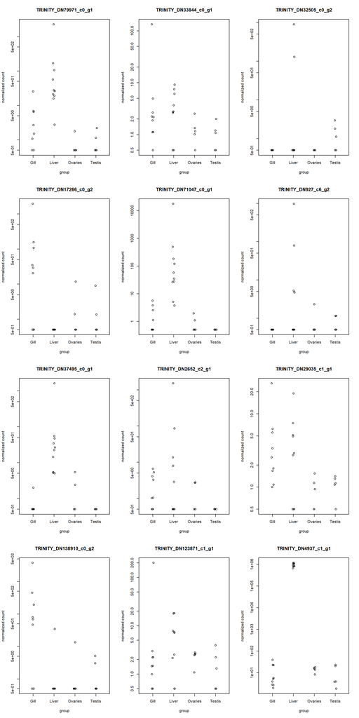

|  | FLG2F7 | FLG3F1 | FLG3F2 | FLG3M5 | FLG3M7 | FLG3M8 | FLG4M3 | FLG4M4 | FLG8F3 | FLL2F7 | FLL3F1 | FLL3F2 | FLL3F4 | FLL3M5 | FLL3M7 | FLL3M8 | FLL4M3 | FLL4M4 | FLL8F3 | FLO2F7 | FLO3F1 | FLO3F2 | FLO3F4 | FLO8F3 | FLT2M3 | FLT3M5 | FLT4M4 | FLT5M3 | FLT8M7 |
| --- | --- | --- | --- | --- | --- | --- | --- | --- | --- | --- | --- | --- | --- | --- | --- | --- | --- | --- | --- | --- | --- | --- | --- | --- | --- | --- | --- | --- | --- |
| TRINITY_DN3390_c5_g1 | 1.915322 | 1.191699 | 1.374606 | 1.283282 | 0.648988 | 0.293973 | 0.086935 | 0.47156 | 0 | 0 | 0.752944 | 0.166046 | 0 | 0.648803 | 0 | 0.167483 | 0.07965 | 0 | 0 | 1.339849 | 1.243675 | 1.719132 | 1.212814 | 0.894546 | 797.6304 | 1766.4 | 5728.606 | 9424.542 | 1389.621 |

```
## using 'avgTxLength' from assays(dds), correcting for library size
```

|  | FLG2F7 | FLG3F1 | FLG3F2 | FLG3M5 | FLG3M7 | FLG3M8 | FLG4M3 | FLG4M4 | FLG8F3 | FLL2F7 | FLL3F1 | FLL3F2 | FLL3F4 | FLL3M5 | FLL3M7 | FLL3M8 | FLL4M3 | FLL4M4 | FLL8F3 | FLO2F7 | FLO3F1 | FLO3F2 | FLO3F4 | FLO8F3 | FLT2M3 | FLT3M5 | FLT4M4 | FLT5M3 | FLT8M7 |
| --- | --- | --- | --- | --- | --- | --- | --- | --- | --- | --- | --- | --- | --- | --- | --- | --- | --- | --- | --- | --- | --- | --- | --- | --- | --- | --- | --- | --- | --- |
| TRINITY_DN168500_c0_g1 | 0 | 0.942199 | 1.553451 | 0.288835 | 1.454043 | 2.409941 | 0 | 0 | 0.234851 | 7007.593 | 6960.66 | 8191.516 | 7611.868 | 8648.97 | 10103.08 | 6255.89 | 10745.12 | 14742.49 | 16709.12 | 1.533473 | 0 | 1.228352 | 2.847534 | 0 | 0 | 1.11452 | 0 | 0.398892 | 0.356016 |

```
## using 'avgTxLength' from assays(dds), correcting for library size
```

|  | FLG2F7 | FLG3F1 | FLG3F2 | FLG3M5 | FLG3M7 | FLG3M8 | FLG4M3 | FLG4M4 | FLG8F3 | FLL2F7 | FLL3F1 | FLL3F2 | FLL3F4 | FLL3M5 | FLL3M7 | FLL3M8 | FLL4M3 | FLL4M4 | FLL8F3 | FLO2F7 | FLO3F1 | FLO3F2 | FLO3F4 | FLO8F3 | FLT2M3 | FLT3M5 | FLT4M4 | FLT5M3 | FLT8M7 |
| --- | --- | --- | --- | --- | --- | --- | --- | --- | --- | --- | --- | --- | --- | --- | --- | --- | --- | --- | --- | --- | --- | --- | --- | --- | --- | --- | --- | --- | --- |
| TRINITY_DN125448_c0_g1 | 0 | 0.313606 | 1.413377 | 0.186909 | 1.835993 | 3.2061 | 1.621366 | 0.423442 | 1.131618 | 18283.77 | 22189.16 | 15420.11 | 22303.16 | 7284.046 | 14130.52 | 16768.33 | 17550.15 | 20049.69 | 22558.86 | 0.619148 | 0 | 2.096597 | 0 | 0 | 0.456869 | 0 | 0 | 0 | 0.221689 |

```
## using 'avgTxLength' from assays(dds), correcting for library size
```

|  | FLG2F7 | FLG3F1 | FLG3F2 | FLG3M5 | FLG3M7 | FLG3M8 | FLG4M3 | FLG4M4 | FLG8F3 | FLL2F7 | FLL3F1 | FLL3F2 | FLL3F4 | FLL3M5 | FLL3M7 | FLL3M8 | FLL4M3 | FLL4M4 | FLL8F3 | FLO2F7 | FLO3F1 | FLO3F2 | FLO3F4 | FLO8F3 | FLT2M3 | FLT3M5 | FLT4M4 | FLT5M3 | FLT8M7 |
| --- | --- | --- | --- | --- | --- | --- | --- | --- | --- | --- | --- | --- | --- | --- | --- | --- | --- | --- | --- | --- | --- | --- | --- | --- | --- | --- | --- | --- | --- |
| TRINITY_DN2737_c10_g1 | 0 | 0 | 1.253771 | 0 | 2.89316 | 1.865081 | 0 | 0 | 0 | 12006.16 | 17338.61 | 14526.94 | 17942.09 | 9629.504 | 13219.28 | 15319.45 | 23167.47 | 9311.478 | 15759.04 | 0 | 0 | 2.6697 | 0 | 0.59965 | 0 | 0 | 0 | 0 | 0 |

```
## using 'avgTxLength' from assays(dds), correcting for library size
```

|  | FLG2F7 | FLG3F1 | FLG3F2 | FLG3M5 | FLG3M7 | FLG3M8 | FLG4M3 | FLG4M4 | FLG8F3 | FLL2F7 | FLL3F1 | FLL3F2 | FLL3F4 | FLL3M5 | FLL3M7 | FLL3M8 | FLL4M3 | FLL4M4 | FLL8F3 | FLO2F7 | FLO3F1 | FLO3F2 | FLO3F4 | FLO8F3 | FLT2M3 | FLT3M5 | FLT4M4 | FLT5M3 | FLT8M7 |
| --- | --- | --- | --- | --- | --- | --- | --- | --- | --- | --- | --- | --- | --- | --- | --- | --- | --- | --- | --- | --- | --- | --- | --- | --- | --- | --- | --- | --- | --- |
| TRINITY_DN150289_c0_g1 | 0 | 0 | 0 | 0 | 0 | 0 | 0 | 0 | 0 | 0 | 0 | 0 | 0 | 0 | 0 | 0 | 0 | 0 | 0 | 14452.83 | 7087.196 | 7599.357 | 12631.54 | 13082.83 | 0.286077 | 0.346457 | 0 | 0 | 0.569997 |

```
## using 'avgTxLength' from assays(dds), correcting for library size
```

|  | FLG2F7 | FLG3F1 | FLG3F2 | FLG3M5 | FLG3M7 | FLG3M8 | FLG4M3 | FLG4M4 | FLG8F3 | FLL2F7 | FLL3F1 | FLL3F2 | FLL3F4 | FLL3M5 | FLL3M7 | FLL3M8 | FLL4M3 | FLL4M4 | FLL8F3 | FLO2F7 | FLO3F1 | FLO3F2 | FLO3F4 | FLO8F3 | FLT2M3 | FLT3M5 | FLT4M4 | FLT5M3 | FLT8M7 |
| --- | --- | --- | --- | --- | --- | --- | --- | --- | --- | --- | --- | --- | --- | --- | --- | --- | --- | --- | --- | --- | --- | --- | --- | --- | --- | --- | --- | --- | --- |
| TRINITY_DN3_c0_g1 | 0.096025 | 0.0326 | 0.027709 | 0.080982 | 0.018051 | 0.10282 | 0.032907 | 0.040528 | 0.013272 | 0.029741 | 0.025211 | 0.50325 | 0.631 | 0.47946 | 0.159477 | 0.041036 | 0.008677 | 0.051655 | 0.158885 | 0.095594 | 0.125921 | 0.175559 | 0.241228 | 0.104543 | 453.2654 | 614.722 | 1815.225 | 2541.909 | 445.8102 |

```
## using 'avgTxLength' from assays(dds), correcting for library size
```

|  | FLG2F7 | FLG3F1 | FLG3F2 | FLG3M5 | FLG3M7 | FLG3M8 | FLG4M3 | FLG4M4 | FLG8F3 | FLL2F7 | FLL3F1 | FLL3F2 | FLL3F4 | FLL3M5 | FLL3M7 | FLL3M8 | FLL4M3 | FLL4M4 | FLL8F3 | FLO2F7 | FLO3F1 | FLO3F2 | FLO3F4 | FLO8F3 | FLT2M3 | FLT3M5 | FLT4M4 | FLT5M3 | FLT8M7 |
| --- | --- | --- | --- | --- | --- | --- | --- | --- | --- | --- | --- | --- | --- | --- | --- | --- | --- | --- | --- | --- | --- | --- | --- | --- | --- | --- | --- | --- | --- |
| TRINITY_DN105340_c0_g1 | 7472.732 | 2082.841 | 1893.741 | 3040.507 | 6876.184 | 6735.64 | 2266.581 | 2.794158 | 550.1212 | 0 | 0 | 0 | 0 | 0 | 0 | 0 | 0 | 0 | 0 | 0 | 0 | 0 | 0 | 0 | 0 | 1.990756 | 0 | 0 | 0.872494 |

```
## using 'avgTxLength' from assays(dds), correcting for library size
```

|  | FLG2F7 | FLG3F1 | FLG3F2 | FLG3M5 | FLG3M7 | FLG3M8 | FLG4M3 | FLG4M4 | FLG8F3 | FLL2F7 | FLL3F1 | FLL3F2 | FLL3F4 | FLL3M5 | FLL3M7 | FLL3M8 | FLL4M3 | FLL4M4 | FLL8F3 | FLO2F7 | FLO3F1 | FLO3F2 | FLO3F4 | FLO8F3 | FLT2M3 | FLT3M5 | FLT4M4 | FLT5M3 | FLT8M7 |
| --- | --- | --- | --- | --- | --- | --- | --- | --- | --- | --- | --- | --- | --- | --- | --- | --- | --- | --- | --- | --- | --- | --- | --- | --- | --- | --- | --- | --- | --- |
| TRINITY_DN30747_c0_g1 | 0 | 0 | 0 | 0 | 0 | 0 | 0 | 0 | 0 | 0 | 0 | 0 | 0 | 0 | 0 | 0.570495 | 0.019432 | 0 | 0 | 0.18223 | 0.402248 | 0.198879 | 0 | 0.016844 | 0.107019 | 0.017097 | 0.030756 | 0.180107 | 0.296205 |

```
## using 'avgTxLength' from assays(dds), correcting for library size
```

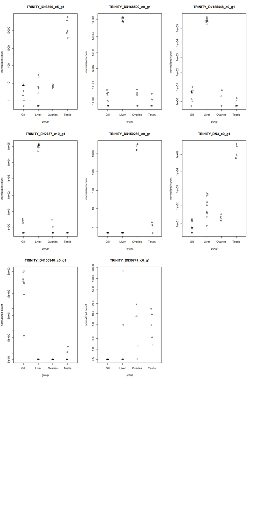

# 1 Sex Bias and Tissue Specificity

From the DESeq2 analysis we can pull out the FC information for all of the sex biased genes and plot that against the $\tau$ calculations.

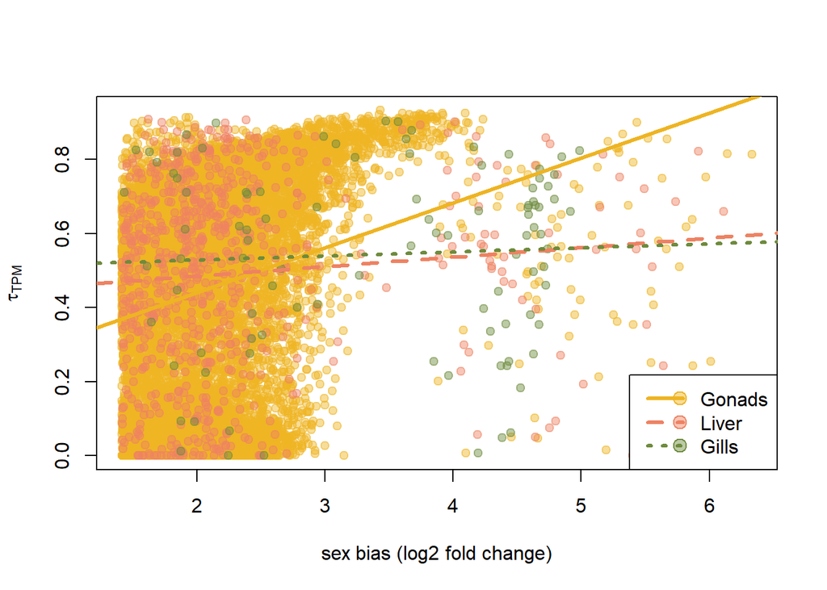

Sex bias (in terms of the absolute value of the log2FoldChange) versus tissue specificity (tau) for all genes that are sex biased in the gonads, liver, and gills.

```
##
##  Spearman's rank correlation rho
##
## data:  gonad_bias_tau$tau and abs(gonad_bias_tau$log2FoldChange)
## S = 2.7911e+11, p-value < 2.2e-16
## alternative hypothesis: true rho is not equal to 0
## sample estimates:
##       rho
## 0.2120436
```

```
##
##  Spearman's rank correlation rho
##
## data:  liver_bias_tau$tau and abs(liver_bias_tau$log2FoldChange)
## S = 70362832, p-value = 0.0003511
## alternative hypothesis: true rho is not equal to 0
## sample estimates:
##       rho
## 0.1272572
```

```
##
##  Spearman's rank correlation rho
##
## data:  gill_bias_tau$tau and abs(gill_bias_tau$log2FoldChange)
## S = 158225, p-value = 0.8328
## alternative hypothesis: true rho is not equal to 0
## sample estimates:
##        rho
## 0.02149048
```

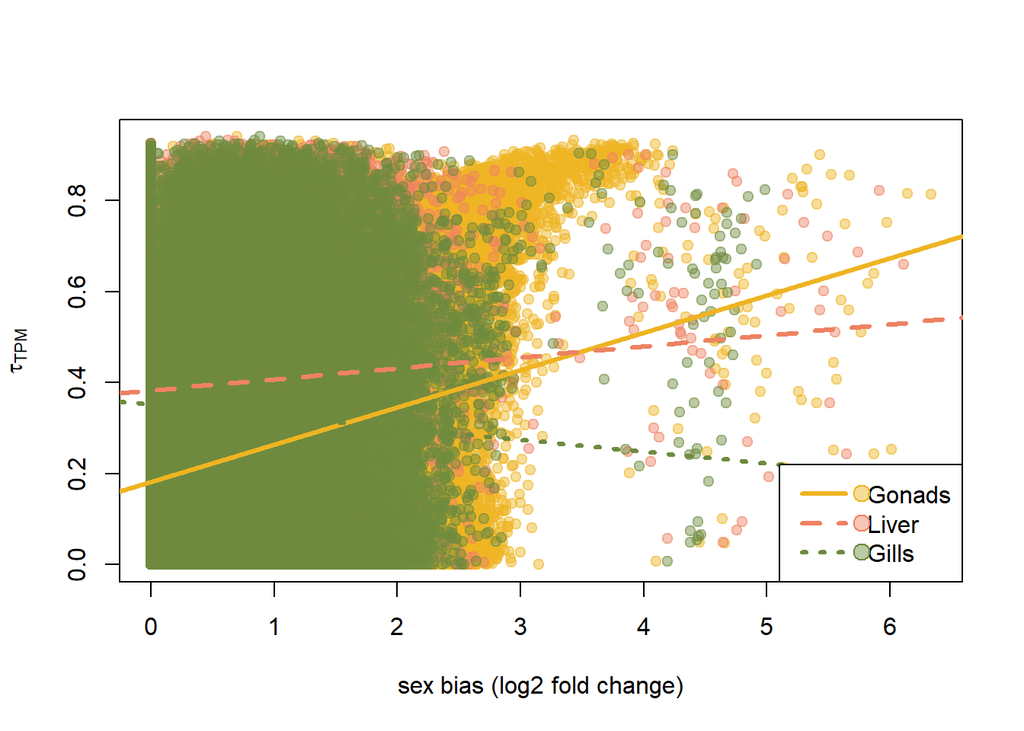

Sex bias (in terms of the absolute value of the log2FoldChange) versus tissue specificity (tau) for all genes that are signifcantly expressed in the gonads, liver, and gills.

```
##
##  Spearman's rank correlation rho
##
## data:  gonad_bias_tau_all$tau and abs(gonad_bias_tau_all$log2FoldChange)
## S = 8.699e+13, p-value < 2.2e-16
## alternative hypothesis: true rho is not equal to 0
## sample estimates:
##       rho
## 0.1772599
```

```
##
##  Spearman's rank correlation rho
##
## data:  liver_bias_tau_all$tau and abs(liver_bias_tau_all$log2FoldChange)
## S = 8.5996e+12, p-value < 2.2e-16
## alternative hypothesis: true rho is not equal to 0
## sample estimates:
##        rho
## 0.04882487
```

```
##
##  Spearman's rank correlation rho
##
## data:  gill_bias_tau_all$tau and abs(gill_bias_tau_all$log2FoldChange)
## S = 3.7499e+13, p-value < 2.2e-16
## alternative hypothesis: true rho is not equal to 0
## sample estimates:
##         rho
## -0.09779226
```

```
## using 'avgTxLength' from assays(dds), correcting for library size
```

```
## -- replacing outliers and refitting for 37383 genes
## -- DESeq argument 'minReplicatesForReplace' = 7
## -- original counts are preserved in counts(dds)
```

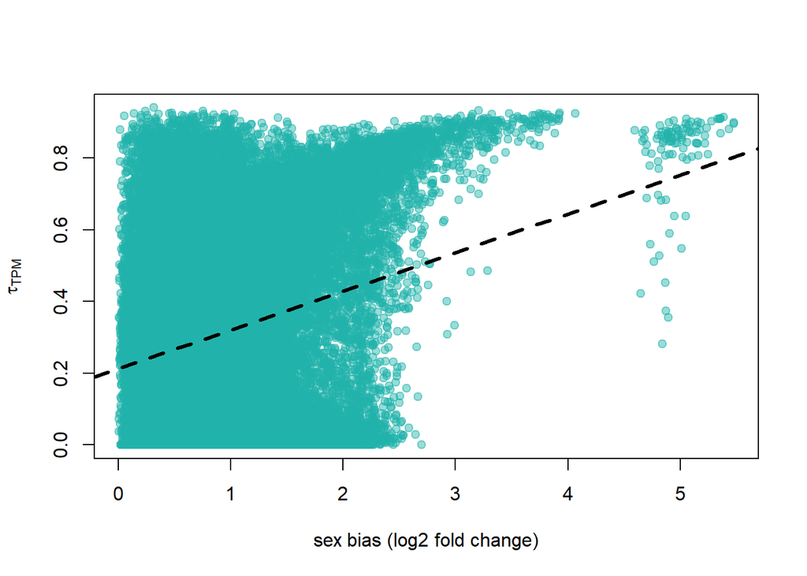

Sex bias (in terms of the absolute value of the log2FoldChange) versus tissue specificity (tau) for all genes that are signifcantly expressed. The fold change in this plot is a difference bewteen males and females regardless of tissue type.

```
##
##  Spearman's rank correlation rho
##
## data:  MFbias_tau_all$tau and abs(MFbias_tau_all$log2FoldChange)
## S = 3.6718e+13, p-value < 2.2e-16
## alternative hypothesis: true rho is not equal to 0
## sample estimates:
##       rho
## 0.1254565
```

To further investigate this I categorized the sex biased genes based on a series of logFC thresholds to see if we can get a better idea about what relationship may lie between sex bias and $\tau$. After that I can plot $\tau$ against the bias level.

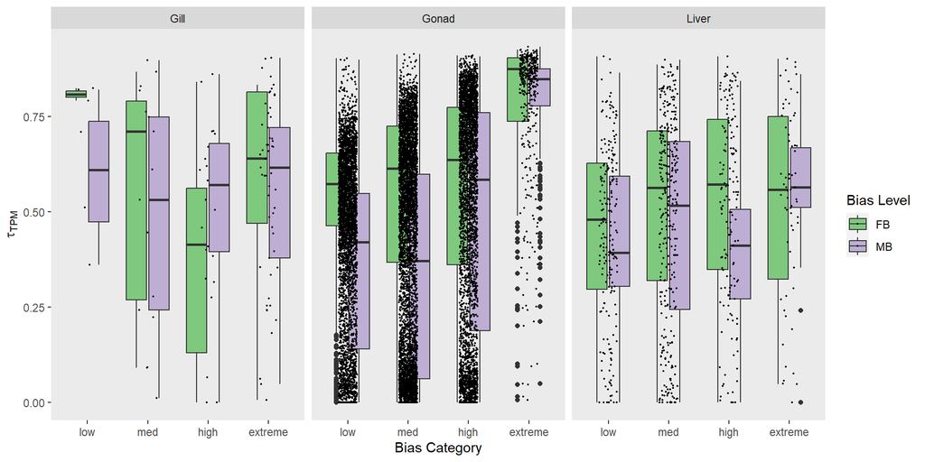

Tissue specifcity (tau) across the different bias levels. Color denotes female-biased versus male biased and jitters were added to show all of the raw tau values.

[figure not shown]

```r
plot(sqrt(abs(logFC_long$logFC)),
     logFC_long$tau,
     pch=19,
     col = "#20B2AA75",
     xlab="sex bias (log2 fold change)",
     ylab=expression(tau["TPM"]))
abline(lm(logFC_long$tau ~ sqrt(abs(logFC_long$logFC))), lwd = 2.5, lty = 2)
```

```r
cor.test(logFC_long$tau, sqrt(abs(logFC_long$logFC)), method = "spearman")
```

```
##
##  Spearman's rank correlation rho
##
## data:  logFC_long$tau and sqrt(abs(logFC_long$logFC))
## S = 3.4264e+11, p-value < 2.2e-16
## alternative hypothesis: true rho is not equal to 0
## sample estimates:
##      rho
## 0.207623
```

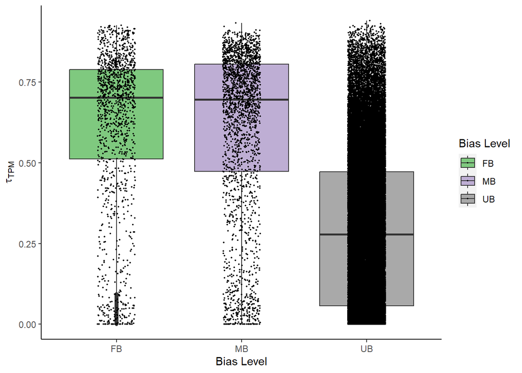